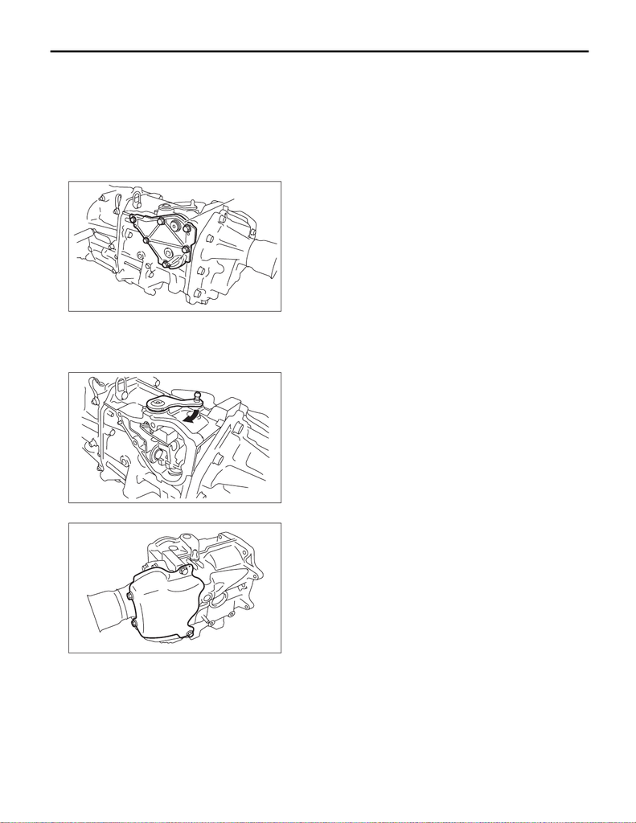

6MT(TY75)-51

Transfer Case and Extension Case Assembly

MANUAL TRANSMISSION AND DIFFERENTIAL

10.Transfer Case and Extension Case Assembly

A: REMOVAL

1) Remove the manual transmission assembly from the vehicle. <Ref. to 6MT(TY75)-25, REMOVAL, Manual

Transmission Assembly.>

2) Remove the back-up light switch and the neutral position switch. <Ref. to 6MT(TY75)-45, REMOVAL,

Switches and Harness.>

3) Remove the transfer case together with the extension case assembly.

(1) Remove the transmission cover.

(2) Set and hold the selector lever COMPL to the 1st-2nd side, and remove the transfer case and exten-

sion case assembly as a unit.

4) Remove the transfer cover.

MT-02981

(A)

(A) Transmission cover

MT-02449

MT-02450

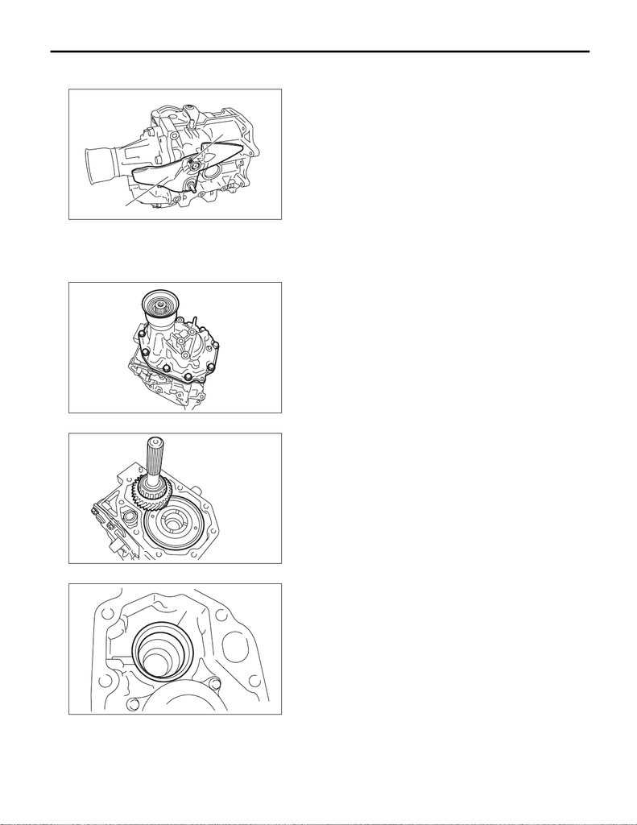

6MT(TY75)-52

Transfer Case and Extension Case Assembly

MANUAL TRANSMISSION AND DIFFERENTIAL

5) Use the ST to push out the spring pin, and remove the shift lever COMPL.

ST 398791700 SPRING PIN REMOVER 2

6) Remove the extension case assembly.

7) Remove the transfer driven gear and center differential as a unit.

8) Remove the taper roller bearing (extension case side) outer race and the adjusting washer.

MT-02451

(B)

(A)

(A) Shift lever COMPL

(B) Straight pin

MT-02452

MT-01893

MT-02301

(A)

(A) Taper roller bearing (extension case side) outer

race

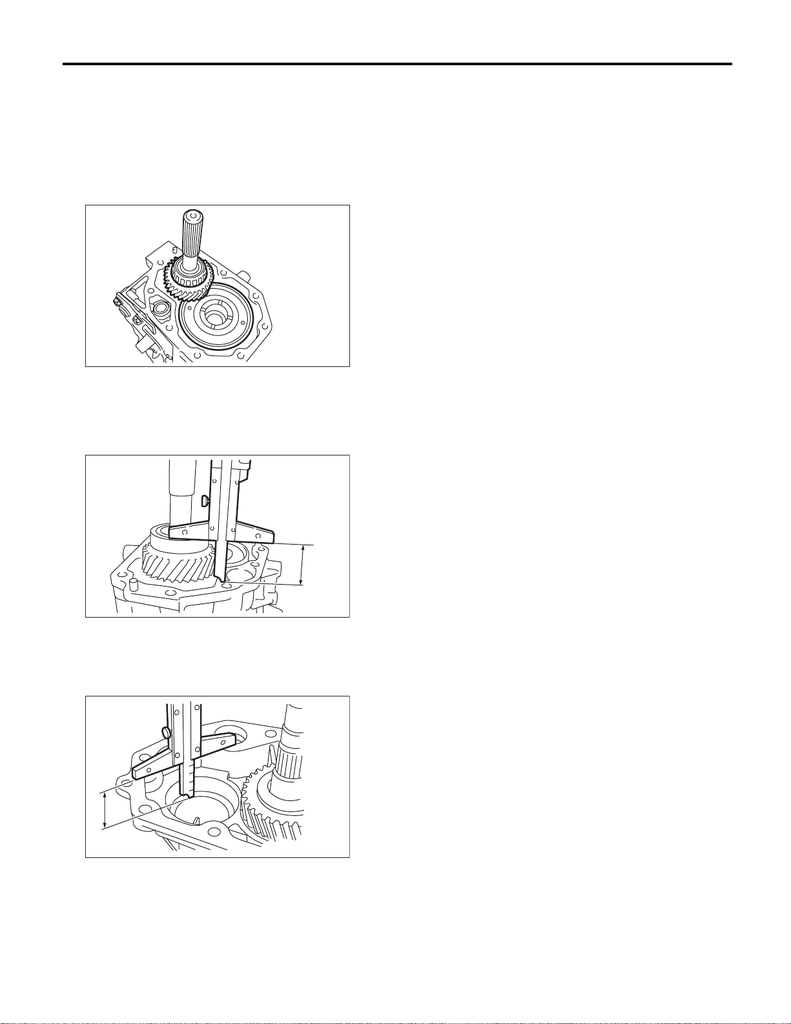

6MT(TY75)-53

Transfer Case and Extension Case Assembly

MANUAL TRANSMISSION AND DIFFERENTIAL

B: INSTALLATION

1) Clean the mating surfaces of the transmission case, transfer case and extension case.

2) Apply a coat of grease to the taper roller bearing (transfer case side) of transfer driven gear and the roller

rolling surface of the taper roller bearing (extension case side).

Grease:

NICHIMOLY N-130 or equivalent

3) Install the center differential and the transfer driven gear.

4) Install the taper roller bearing (extension case side) outer race to the transfer driven gear.

5) While pressing the taper roller bearing (extension case side) outer race horizontally, rotate the transfer

driven gear for ten turns.

6) Measure the height “W” between transfer case and taper roller bearing (transfer case side) on the transfer

driven gear.

7) Measure the depth “X” of taper roller bearing insertion part of the extension case.

NOTE:

Measure while the taper roller bearing (extension case side) outer race and the adjusting washer are re-

moved.

MT-01893

MT-00120

W

MT-00121

X

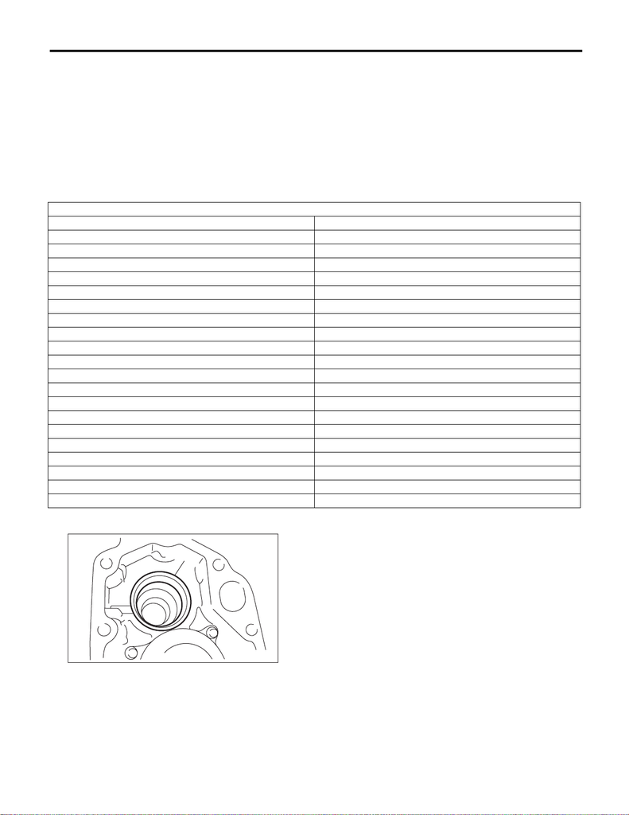

6MT(TY75)-54

Transfer Case and Extension Case Assembly

MANUAL TRANSMISSION AND DIFFERENTIAL

8) Calculate the adjusting washer thickness “t” using the following calculation.

t = X – W + (0.15 — 0.2 mm (0.006 — 0.008 in))

X: Depth of taper roller bearing insertion part of extension case

W: Height between transfer case and taper roller bearing (transfer case side) on transfer driven gear

0.15 — 0.20 mm (0.006 — 0.008 in): Amount of standard protrusion

9) Select the adjusting washer with the nearest value in the following table.

NOTE:

Be sure that it is always within the preload.

Preload of taper roller bearing (extension case side) (amount of standard protrusion):

0.15 — 0.20 mm (0.006 — 0.008 in)

10) Install the selected adjusting washer and taper roller bearing (extension case side) outer race.

Adjusting washer (50 × 61 × t)

Part No. Thickness mm (in)

803050060 0.50 (0.0197)

803050061 0.55 (0.0217)

803050062 0.60 (0.0236)

803050063 0.65 (0.0256)

803050064 0.70 (0.0276)

803050065 0.75 (0.0295)

803050066 0.80 (0.0315)

803050067 0.85 (0.0335)

803050068 0.90 (0.0354)

803050069 0.95 (0.0374)

803050070 1.00 (0.0394)

803050071 1.05 (0.0413)

803050072 1.10 (0.0433)

803050073 1.15 (0.0453)

803050074 1.20 (0.0472)

803050075 1.25 (0.0492)

803050076 1.30 (0.0512)

803050077 1.35 (0.0531)

803050078 1.40 (0.0551)

803050079 1.45 (0.0571)

MT-02301

(A)

(A) Taper roller bearing (extension case side) outer

race

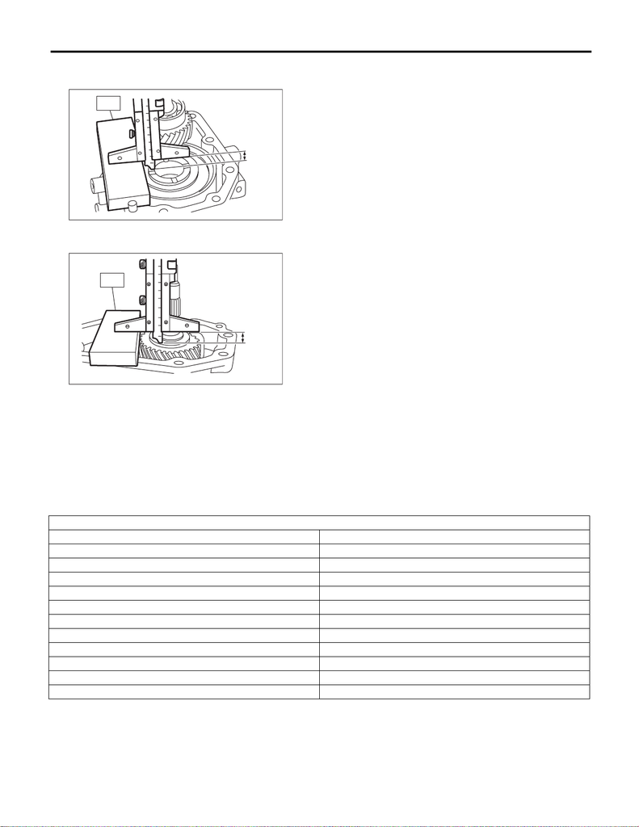

6MT(TY75)-55

Transfer Case and Extension Case Assembly

MANUAL TRANSMISSION AND DIFFERENTIAL

11) Measure the depth “S” between the transfer case + ST and the center differential.

ST 398643600 GAUGE

12) Measure the height “T” between the extension case + ST and the transfer drive gear.

ST 398643600 GAUGE

13) Calculate the adjusting washer thickness “U” using the following calculation.

U = S + T – 30 mm (1.18 in) – (0.15 — 0.35 mm (0.0059 — 0.0138 in))

S: Depth between the transfer case + ST and the center differential

T: Height between the extension case + ST and the transfer drive gear

30 mm (1.18 in): Thickness of ST 15 mm (0.59 in) × 2

0.15 — 0.35 mm (0.0059 — 0.0138 in): Clearance

14) Select a suitable adjusting washer in the following table.

Clearance:

0.15 — 0.35 mm (0.0059 — 0.0138 in)

MT-00122

ST

S

MT-00123

T

ST

Adjusting washer

Part No. Thickness mm (in)

803036050 0.9 (0.035)

803036054 1.0 (0.039)

803036051 1.1 (0.043)

803036055 1.2 (0.047)

803036052 1.3 (0.051)

803036056 1.4 (0.055)

803036053 1.5 (0.059)

803036057 1.6 (0.063)

803036058 1.7 (0.067)

803036080 1.8 (0.071)

803036081 1.9 (0.075)

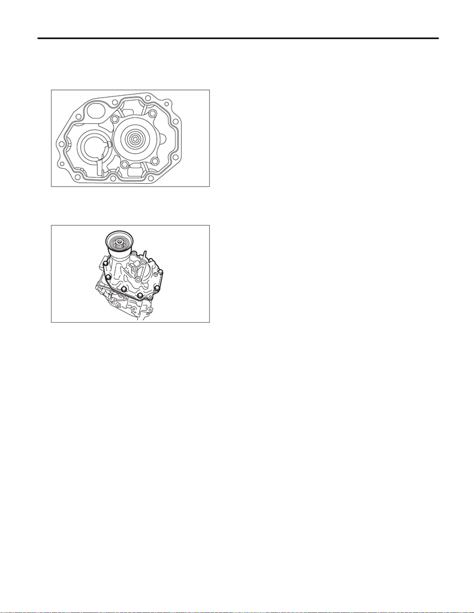

6MT(TY75)-56

Transfer Case and Extension Case Assembly

MANUAL TRANSMISSION AND DIFFERENTIAL

15) Install the adjusting washer to center differential.

16) Apply liquid gasket seamlessly.

Liquid gasket:

THREE BOND 1215B or equivalent

17) Install the extension case assembly.

Tightening torque:

40 N·m (4.1 kgf-m, 29.5 ft-lb)

18) Temporarily install the gasket to the transmission case side.

NOTE:

Use a new gasket.

MT-01993

MT-02452

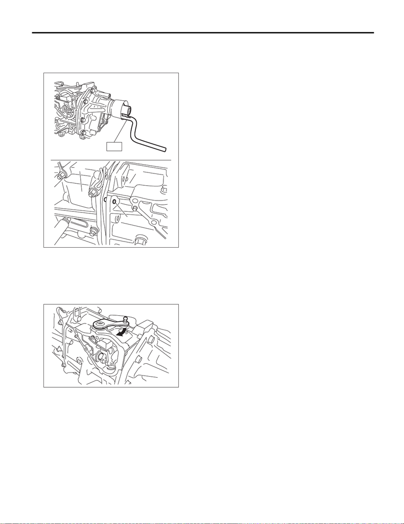

6MT(TY75)-57

Transfer Case and Extension Case Assembly

MANUAL TRANSMISSION AND DIFFERENTIAL

19) Install the transfer case together with the extension case assembly.

(1) While moving the HANDLE to align the spline position, press in the transfer case assembly until the

knock pin comes slightly out of transfer case.

ST 18631AA000 HANDLE

(2) Set and hold the selector lever COMPL to the 1st-2nd side, and install the transfer case assembly so

that the shifter arm edge and fork rod does not contact.

20) Temporarily install the transfer case assembly.

(A)

(B)

(C)

ST

MT-02455

(A) Transmission case

(B) Transfer case

(C) Knock pin

MT-02449

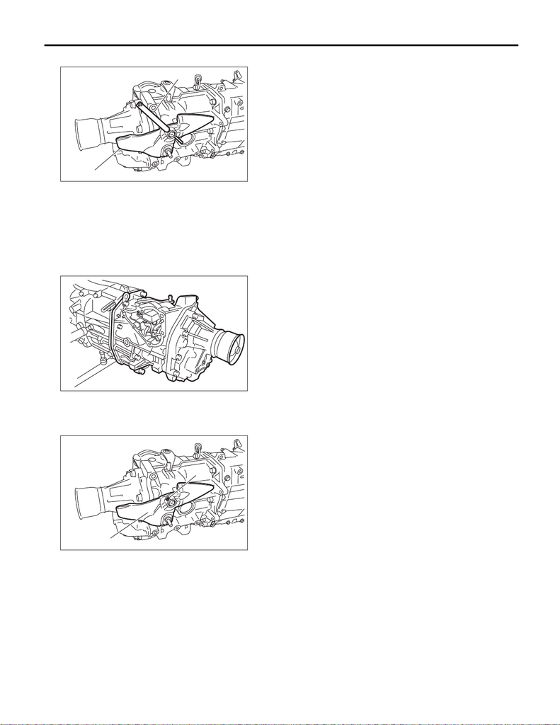

6MT(TY75)-58

Transfer Case and Extension Case Assembly

MANUAL TRANSMISSION AND DIFFERENTIAL

21) Install the shift lever COMPL, then insert the remover or similar tool instead of straight pin.

22) Operate the selector arm and remover to confirm the correct shifting into each gear is possible.

23) Install the transfer case assembly.

Tightening torque:

24.5 N·m (2.5 kgf-m, 18.1 ft-lb)

24) Secure the shift lever COMPL using a straight pin.

NOTE:

Use a new straight pin.

MT-02456

(A)

(B)

(A) Shift lever COMPL

(B) Remover

MT-02559

MT-02457

(B)

(A)

(A) Shift lever COMPL

(B) Straight pin

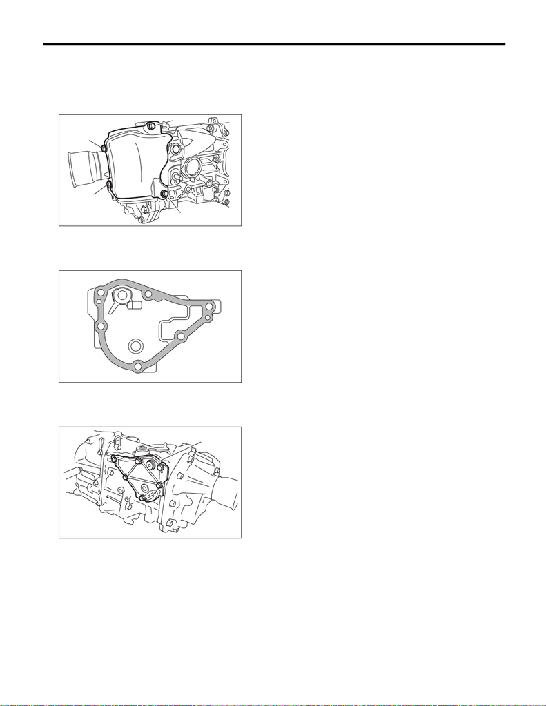

6MT(TY75)-59

Transfer Case and Extension Case Assembly

MANUAL TRANSMISSION AND DIFFERENTIAL

25) Install the transfer cover.

(1) Temporarily install the transfer cover mounting bolts.

(2) Tighten bolts in order of (B), (A), (C), (D).

Tightening torque:

15 N·m (1.5 kgf-m, 11.1 ft-lb)

26) Apply liquid gasket seamlessly.

Liquid gasket:

THREE BOND 1215B or equivalent

27) Install the transmission cover.

Tightening torque:

25 N·m (2.5 kgf-m, 18.4 ft-lb)

28) Install the back-up light switch and the neutral switch. <Ref. to 6MT(TY75)-46, BACK-UP LIGHT AND

NEUTRAL POSITION SWITCH, INSTALLATION, Switches and Harness.>

29) Install the manual transmission assembly to the vehicle. <Ref. to 6MT(TY75)-30, INSTALLATION, Man-

ual Transmission Assembly.>

MT-02458

(A)

(D)

(B)

(C)

MT-02459

MT-02981

(A)

(A) Transmission cover

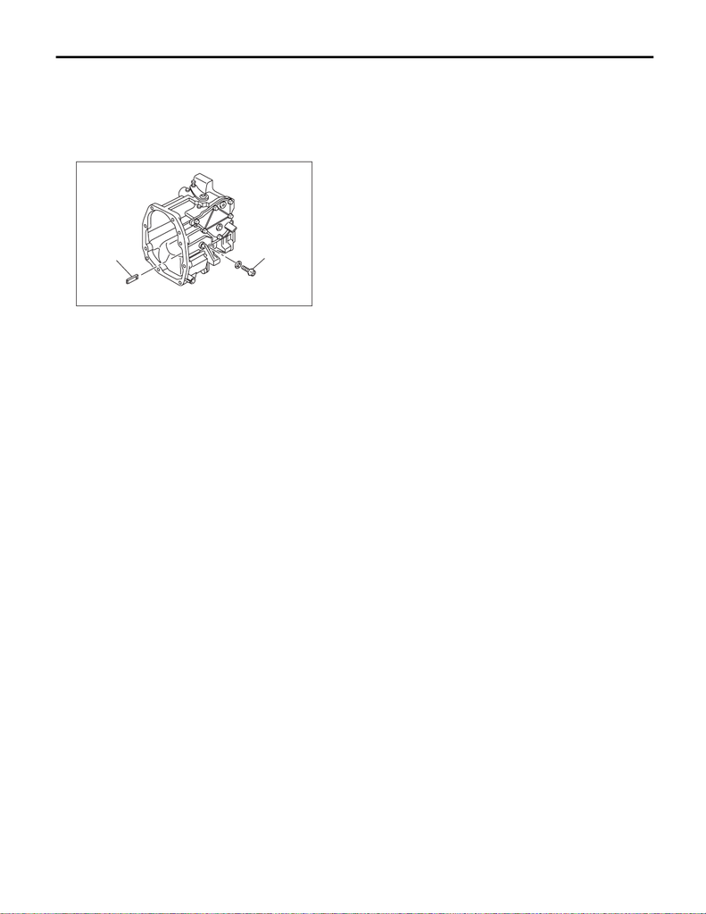

6MT(TY75)-60

Transfer Case and Extension Case Assembly

MANUAL TRANSMISSION AND DIFFERENTIAL

C: DISASSEMBLY

1. TRANSFER CASE

1) Remove the interlock plate.

NOTE:

Do not remove the precoat bolt (B) if the parts are assembled as a transmission assembly.

2) Remove the shift link assembly. <Ref. to 6MT(TY75)-71, REMOVAL, Shift Link Assembly.>

2. EXTENSION CASE

1) Remove the transfer drive gear assembly. <Ref. to 6MT(TY75)-62, REMOVAL, Transfer Drive Gear.>

2) Remove the oil seal from the extension case. <Ref. to 6MT(TY75)-40, REPLACEMENT, Oil Seal.>

3) Remove the dust cover.

MT-02344

(A)

(B)

(A) Interlock plate

(B) Precoat bolt

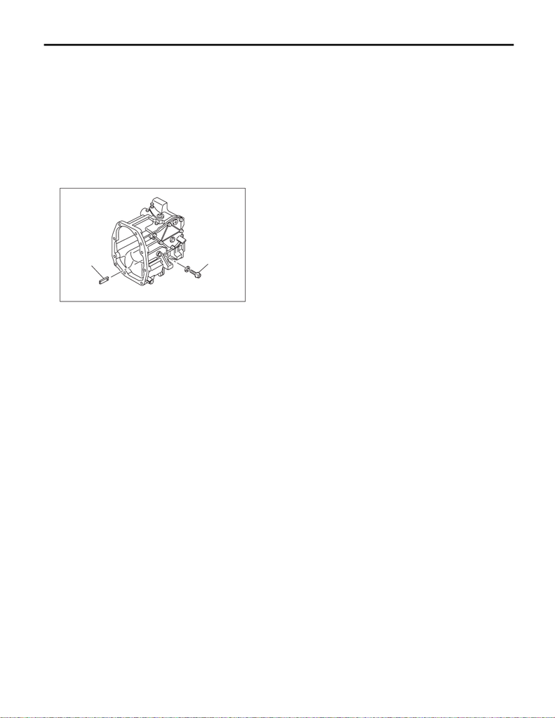

6MT(TY75)-61

Transfer Case and Extension Case Assembly

MANUAL TRANSMISSION AND DIFFERENTIAL

D: ASSEMBLY

1. TRANSFER CASE

1) Install the shift link assembly to the transfer case. <Ref. to 6MT(TY75)-74, INSTALLATION, Shift Link As-

sembly.>

2) Install the interlock plate.

NOTE:

• Use a new bolt and gasket.

• Clean the bolt threads before installing the interlock plate.

Tightening torque:

20 N·m (2.0 kgf-m, 14.8 ft-lb)

2. EXTENSION CASE

1) Using the ST, install the oil seal to the extension case. <Ref. to 6MT(TY75)-40, REPLACEMENT, Oil

Seal.>

NOTE:

Use a new oil seal.

2) Install the dust cover.

3) Install the transfer drive gear to the extension case. <Ref. to 6MT(TY75)-62, INSTALLATION, Transfer

Drive Gear.>

MT-02344

(A)

(B)

(A) Interlock plate

(B) Precoat bolt